# Application

## Application to Longitudinal Study about Children’s Health

In this chapter, we will apply linear mixed models to a longitudinal study about children’s health, and explore how inference of fixed effects can possibly change when using various degrees of freedom approximation methods.

### Background

The National Longitudinal Study of Adolescent to Adult Health is a longitudinal study spanning 1994 to 2008 that surveyed a U.S sample of students in 7-12th grade in the 1994-95 school year [@harris_national_2022]. Four waves of data were collected, in which the sample during the first wave was aged 13-18. Questions about mental health, socioeconomic status, and family background were collected, as well as physical measurements of height and weight.

One question of interest to consider is how salient life experiences that occur during adolescence, such as being exposed to alcohol or being in a physical altercation, may impact changes to one’s physical health over time. One way to capture physical health is through BMI, which is shown to follow a skewed nonnormal distribution [@penman_changing_2006]. With this in mind, we can employ methods of degrees of freedom adjustment. While this dataset is large and encompasses approximately 5,000 students, the scope of this application will be narrowed in order to examine the performance of degrees of freedom methods, which are sensitive to sample size.

We will be focusing on Chinese female respondents who completed at least three waves of the study, which amounts to a sample size of 12. After initial exploration, alcohol use was chosen for the model. It is hypothesized that early exposure to substances could potentially affect changes in weight.

The following variables were assessed in the first wave of the study (1994): - Alcohol: has the child ever had alcohol? (Yes/No) - Age

### Exploration

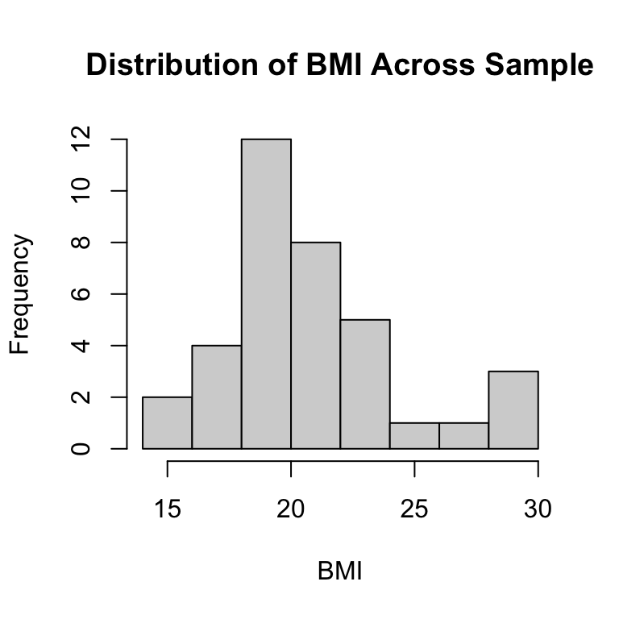

From this histogram depicting distribution of BMI, we can see that it follows a nonnormal trend. The skewness is .95 and the kurtosis is 3.39.

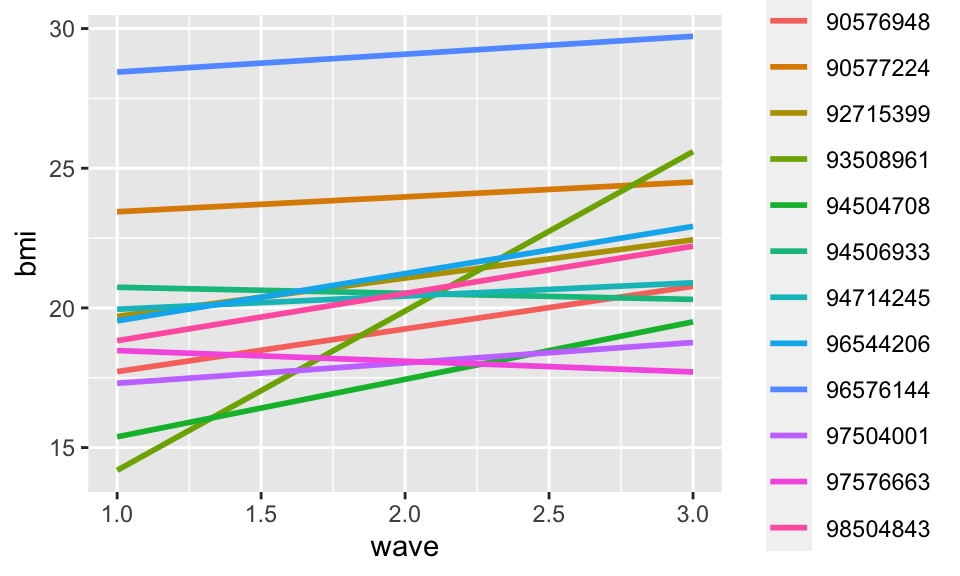

Changes in BMI by Individual

Figure @ref(fig:intercept) depicts changes in BMI over time for each individual in the study. The wide variation in BMI values between individuals suggest that including random effects for the intercept would be beneficial. Additionally, different rates of change in BMI across the 3 waves between individuals would suggest that an additional random effect for time is worth exploring.

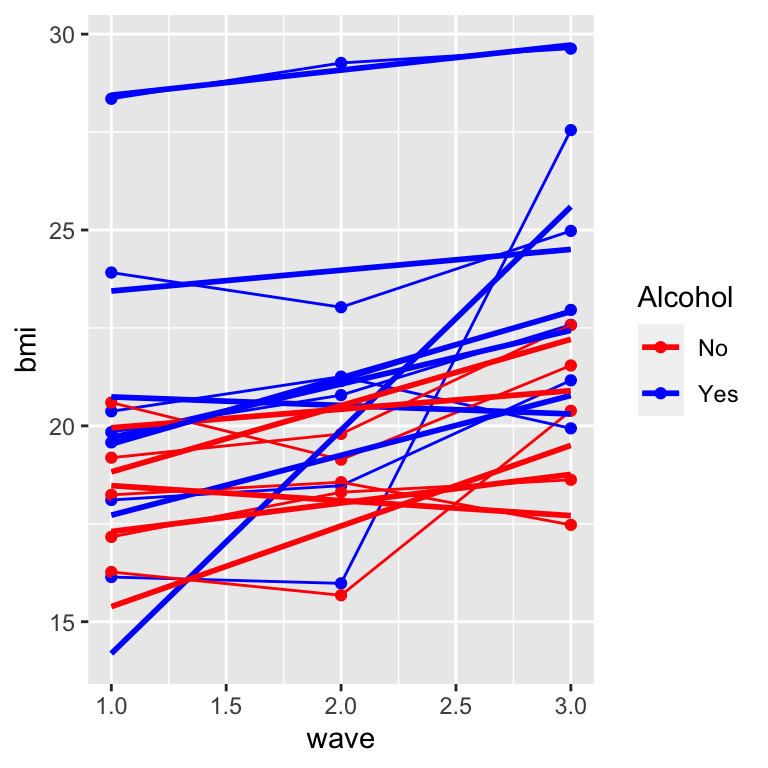

Changes in BMI by Individual and Alcohol Use

While our sample size is small, our initial exploration of alcohol use suggests that it may be salient predictor for BMI. In addition, there are unique patterns of BMI change over time by individual, which suggests that creating a mixed effects model with random effects for time and intercept may be useful.

### Linear Mixed Model

Because we have repeated measurements of the same individual in this study, a regular linear model would not be appropriate as it assumes independence; implementing this model would inflate Type I error rates.

Linear Model Output

| term | estimate | std.error | statistic | p.value |
| --- | --- | --- | --- | --- |
| (Intercept) | 9.7073498 | 4.7363487 | 2.049543 | 0.0486802 |
| alcohol1 | 3.1343922 | 1.0438404 | 3.002750 | 0.0051584 |
| age_at_start | 0.4203997 | 0.2882450 | 1.458480 | 0.1544544 |
| wave | 1.3180180 | 0.6286876 | 2.096459 | 0.0440347 |

Table @ref(tab:lm) shows the results of implementing a linear model with alcohol, age at first wave, and time as predictors. Alcohol use and time are significant predictors in this model. This will only used as a comparison to the other linear mixed models.

### Intercept Only Model

We would hypothesize that changes in weight may vary less within a person, as opposed to comparing changes in weight across two separate individuals. Thus, we fit an intercept only model, allowing the intercept to vary by individual. Alcohol, age at first wave, and time are the fixed effects.

Fixed Effects for Random Intercept Model Using KR

| term | estimate | std.error | statistic | df | p.value |
| --- | --- | --- | --- | --- | --- |
| (Intercept) | 9.7073498 | 7.2738984 | 1.3345457 | 9.224417 | 0.2140289 |
| alcohol1 | 3.1343922 | 1.6525201 | 1.8967347 | 9.000000 | 0.0903586 |
| age_at_start | 0.4203997 | 0.4563252 | 0.9212721 | 9.000000 | 0.3809405 |
| wave | 1.3180180 | 0.4028489 | 3.2717429 | 23.000000 | 0.0033503 |

Random Effects for Random Intercept Model Using KR

| group | term | estimate |
| --- | --- | --- |
| AID | sd__(Intercept) | 2.574188 |
| Residual | sd__Observation | 1.973548 |

First, we can examine the output of the fixed effects similar to how a regular linear regression model is interpreted. Table @ref(tab:interceptKR) shows that time is the only significant effect. This means that conditional on the random effects, each wave increases the predicted BMI by 1.32. Next, we turn to the random effects output in table @ref(tab:interceptr). The variance for individuals (represented by `AID`), which depicts variability across individuals, is 6.626, while the residual variance, representing within-subject variability is 3.895. The significantly larger variance across individuals compared to within individuals suggests that this model is more optimal than a regular linear regression model since differences in variability are apparent. The interclass correlation is .63, which indicates that weight measurements taken of the same individual have slightly higher similarity than those of different individuals.

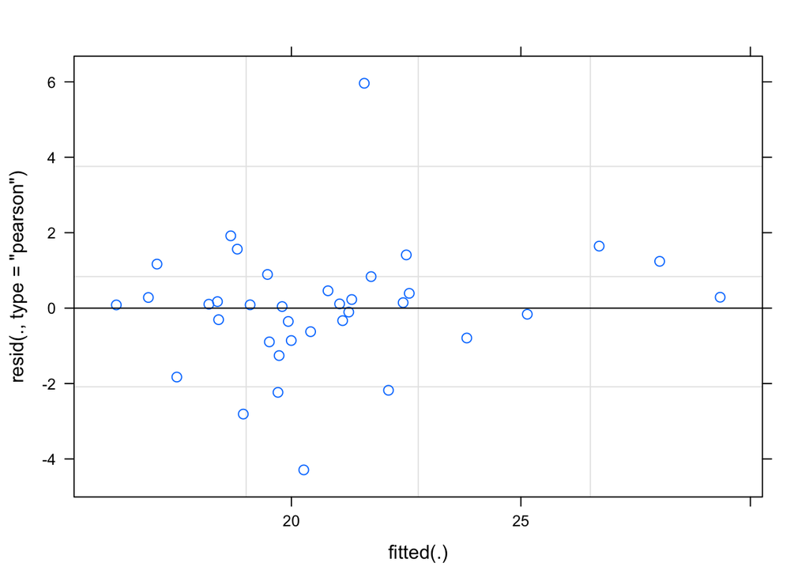

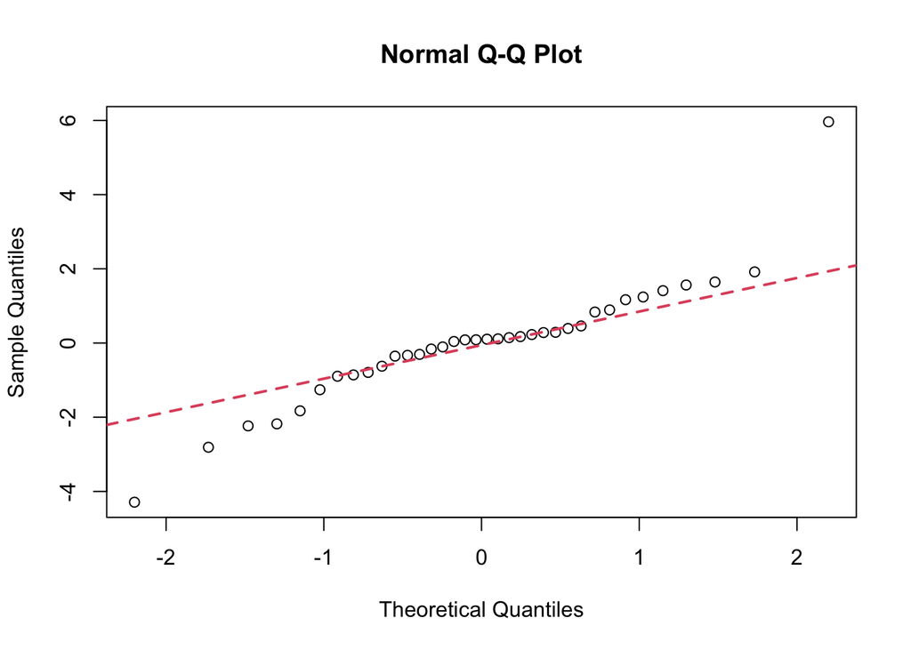

Comparison of Fixed Effects P-Values in Random Intercept Model

| term | Satterthwaite_p.value | KR_p.value |
| --- | --- | --- |
| (Intercept) | 0.214028860057237 | 0.214028858602635 |
| alcohol1 | 0.0903585620561796 | 0.0903585607408565 |
| age_at_start | 0.380940524102144 | 0.380940522986174 |
| wave | 0.00335031625142439 | 0.00335031627116489 |

The summary output referenced above uses Kenward-Roger DF approximation. Table @ref(tab:compareintercept) compares the summary output comparing Satterthwaite and Kenward-Roger. There is no significant difference between performance of the two DF methods, which aligns with results of our random intercept models from our simulation study

### Intercept and random slope

Fixed Effects for Random Slope Model Using KR

| term | estimate | std.error | statistic | df | p.value |
| --- | --- | --- | --- | --- | --- |
| (Intercept) | 11.6444056 | 2.8814232 | 4.041199 | 25.715279 | 0.0004269 |
| alcohol1 | 3.4614666 | 1.6664399 | 2.077163 | 9.637472 | 0.0655425 |
| real_age | 0.3935865 | 0.2088294 | 1.884727 | 16.514642 | 0.0771904 |
| wave | -0.0595346 | 0.8617097 | -0.069089 | 26.697648 | 0.9454337 |

In this model, we add a random effect of time as well as random intercept. This means that we are assuming that for each individual, the relationship between time and BMI is unique. There are no significant effects when using the KR method. Variability in BMI across individuals is 16.388, and the residual variance is 2.352. The variance for time is 1.324, which represents variability across individual’s BMI rates of change. We see that imposing variability between each individual’s relationship of time vs BMI reduces some of the residual variance. When we accounted for some of the variation through each individual’s weight changes over time, time as a predictor was no longer significant as it was in the random intercepts only model.

Conditions for the model are met as seen by the figures below.

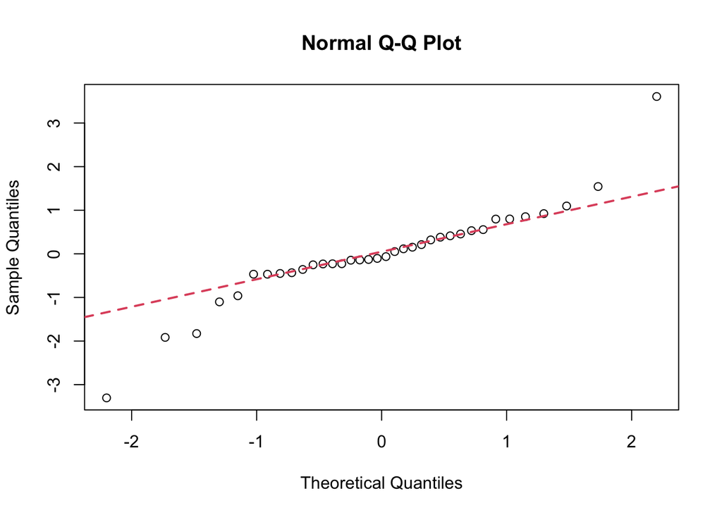

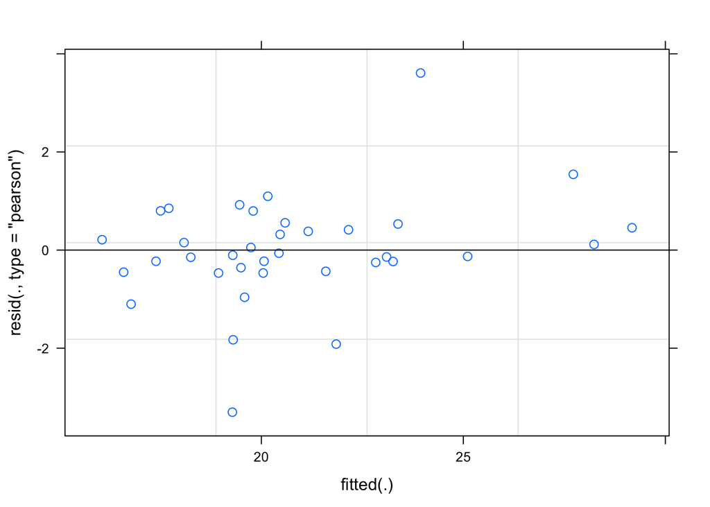

Comparison of Fixed Effects P-Values in Random Slope Model

| term | Satterthwaite_p.value | KR_p.value |
| --- | --- | --- |
| (Intercept) | 0.000213283766249562 | 0.000426895805163504 |
| alcohol1 | 0.0459153731793183 | 0.0655425035327326 |
| real_age | 0.0572004159149207 | 0.0771903662035183 |
| wave | 0.942264459160284 | 0.945433676863754 |

Earlier evaluation of fixed effects uses KR DF method, but @ref(tab:compareslope) shows that significance of fixed effects differ when using Satterthwaite versus KR. In the random slope model, alcohol not a significant effect when using KR, but is significant when using Satterthwaite. This difference affects our interpretation of the model and conclusions that are drawn.

## Discussion

We have demonstrated implementing two linear mixed models on a data set that is small and with a nonnormal continuous outcome. Imposing random effects structure to isolate variation between individuals apart from overall variation improved the model and reduced the number of predictors that were significant. One key result was that comparing KR and Sattherthwaite DF methods resulting in varying significant predictors in the random slope model. One additional predictor, alcohol, was a significant fixed effect when using Satterthwaite, the default output summary for *lmerTest*, in comparison to KR. Which method is preferable?

Ultimately, our application study supports the idea that linear mixed models can be applied to small samples when using KR or Satterthwaite DF methods. While performance between the two can be equally robust in theory, they can possibly lead to different significant fixed effects and conclusions about data overall.